# MATH 1318 - TIME SERIES ANALYSIS - ASSIGNMENT - Final Project

Time Series Analysis of yearly Global Land Temperature Anomalies in Degrees Celsius against the base period 1901-2000

Adeyinka K. Freeman (S3960988)

## **1.0 BACKGROUND**

Time series analysis is a key tool useful in analyzing and forecasting trends, patterns and anomalies in dataset over time. In this assignment, we will be analyzing the year Global Land Temperature Anomalies dataset. The dataset provides insight into temperature variations for the period of 1901-2000. it spans from the year 1850 to 2023 and is sourced from the NOAA National Centers for Environmental Information.

## **1.0.1 Objective**

The primary objective of this study is to perform a comprehensive time series analysis of the Global Land Temperature Anomalies dataset. We also intend to achieve the following: - Conduct descriptive analysis to understand the overall trends and patterns in the temperature anomalies data. - Propose and evaluate a set of possible ARIMA(p, d, q) models using various model specification tools. - Identify the best model using goodness-of-fit metrics (AIC, BIC, MSE, etc).

## **1.0.2 Programming language to be used**

The Assignment will be written in R programming language with descriptive analysis and diagnostic assessments intersperse in the Rmarkdown template used.

## **1.0.3 Loading required Libraries for Time series**

```r
# Load the necessary libraries required for the assignment.

library(tseries) # Time series analysis.
library(readr) # Data import and parsing.
library(ggplot2) # Data visualization and chart creation.

library(dplyr) # data manipulation and transformation
library(forecast) # Time series forecasting.
library(TSA) # Time series analysis and modeling.
library(expsmooth) # Exponential smoothing for time series.
library(lmtest) # Linear regression model testing.
```

## **1.1 DATA PROPROCESSING AND DESCRIPTIVE ANALYSIS**

The Global Land Temperature Anomalies dataset contains yearly temperature anomalies measured in degrees Celsius relative to the base period of 1901-2000. The dataset covers a time span from 1850 to 2023, providing a comprehensive historical record of global land temperature variations.

## **1.1.1 Data import and review**

```r
# Getting working directory for the analysis
getwd()
```

```
## [1] "C:/Users/adeyi/Documents/RMIT classes/Time Series/Assignment 3"
```

```r
# Reading the dataset provided make provision for the presence of header in the CSV file
assignment2Data2024 <- read.csv("~/RMIT classes/Time Series/Assignment1/assignment2Data2024.csv", header = TRUE)

# Glimpse columns
glimpse (assignment2Data2024)
```

```
## Rows: 174
## Columns: 2
## $ Year    <int> 1850, 1851, 1852, 1853, 1854, 1855, 1856, 1857, 1858, 1859, 18…
## $ Anomaly <dbl> -0.06, 0.00, 0.03, 0.01, -0.02, 0.01, -0.10, -0.15, -0.10, 0.0…
```

The “assignment2Data2024” dataset consists of two columns: “Year” and “Anomaly.” The “Year” column covers the years from 1850 to 2023, providing a comprehensive historical record. On the other hand, the “Anomaly” column represents the yearly Global Land Temperature Anomalies measured in degrees Celsius. These anomalies are calculated against the base period of 1901-2000, indicating deviations from the average temperatures during that time frame.

## **1.1.2 Data Preprocessing**

```r
# Check the class of the 'assignment2Data2024' object
class(assignment2Data2024)
```

```
## [1] "data.frame"
```

```r
# Explore the structure of the 'assignment2Data2024' object
str(assignment2Data2024)
```

```
## 'data.frame':    174 obs. of  2 variables:
##  $ Year   : int  1850 1851 1852 1853 1854 1855 1856 1857 1858 1859 ...
##  $ Anomaly: num  -0.06 0 0.03 0.01 -0.02 0.01 -0.1 -0.15 -0.1 0.02 ...
```

```r
# Display the first few rows of the 'assignment2Data2024' object
head(assignment2Data2024)
```

```
##   Year Anomaly
## 1 1850   -0.06
## 2 1851    0.00
## 3 1852    0.03
## 4 1853    0.01
## 5 1854   -0.02
## 6 1855    0.01
```

```r
# Display the last few rows of the 'assignment2Data2024' object
tail(assignment2Data2024)
```

```
##     Year Anomaly
## 169 2018    0.66
## 170 2019    0.74
## 171 2020    0.73
## 172 2021    0.63
## 173 2022    0.67
## 174 2023    0.91
```

```r
#checking out the summary of our dataset
summary(assignment2Data2024)
```

```
##       Year         Anomaly
##  Min.   :1850   Min.   :-0.44000
##  1st Qu.:1893   1st Qu.:-0.12750
##  Median :1936   Median : 0.00000
##  Mean   :1936   Mean   : 0.06218
##  3rd Qu.:1980   3rd Qu.: 0.23000
##  Max.   :2023   Max.   : 0.91000
```

The temperature anomalies in the dataset range from negative values, indicating cooler-than-average temperatures, to positive values, indicating warmer-than-average temperatures. This dataset is intended for time series analysis, which will involve examining trends, patterns, and forecasting of global land temperature anomalies over the years.

## **1.1.3 Viewing, inspecting and Converting the Dataset to Time series**

```r
# Convert the dataset into a time series object using the ts() function
ts_assignment2Data2024 <- ts(assignment2Data2024$Anomaly, start = 1850, end = 2023, frequency = 1)

# Check the structure of the time series object
str(ts_assignment2Data2024)
```

```
##  Time-Series [1:174] from 1850 to 2023: -0.06 0 0.03 0.01 -0.02 0.01 -0.1 -0.15 -0.1 0.02 ...
```

```r
# class of the converted data
class(ts_assignment2Data2024)
```

```
## [1] "ts"
```

```r
# Check the range of the resulting time series
range(ts_assignment2Data2024)
```

```
## [1] -0.44  0.91
```

```r
# Check the summary of the resulting time series
summary(ts_assignment2Data2024)
```

```
##     Min.  1st Qu.   Median     Mean  3rd Qu.     Max.
## -0.44000 -0.12750  0.00000  0.06218  0.23000  0.91000
```

The time series objects are organized as follows:

- ‘assignment2Data2024_ts’ has observation with a range from -0.44 to 0.91,
- Minimum value of the range is -0.44000,
- The 1st Quartile is -0.12750,
- The Median of the series is 0.00000,
- The Mean of the time series is 0.06218,
- The 3rd Quartile is 0.23000,
- The maximum value of the range is 0.91000,

The summary information provided is valuable for understanding the characteristics of each time series, including the range of values and measures of central tendency. It can assist in further analysis and modeling of the data, particularly in the context of time series forecasting.”

## **1.2 DATA VISUALIZATION**

## **1.2.1 Data Visualization - Time series Plot**

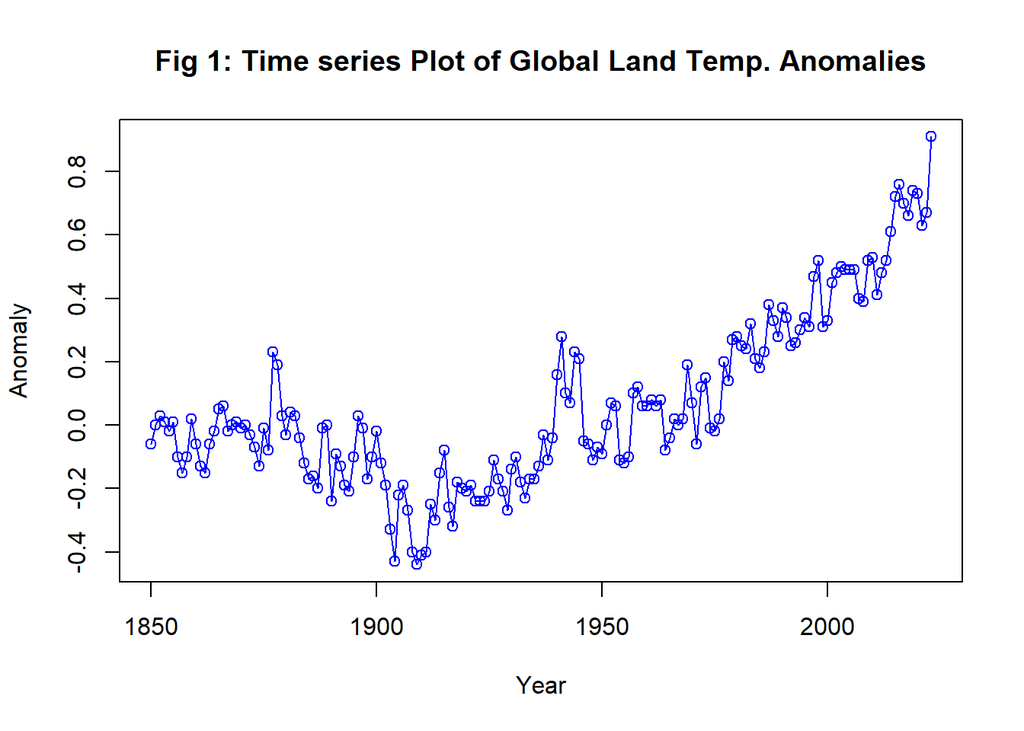

```r
# Create a time series plot and add axis labels

plot(ts_assignment2Data2024, ylab = 'Anomaly', xlab = 'Year', type ='o', main = "Fig 1: Time series Plot of Global Land Temp. Anomalies", col="blue")
```

Visual inspection of the plot above shows:-

Trend Analysis -: The time series plot reveals a progressively upward and positive trend from 1850 to 2023. There were however an observable downward trend between 1877 & 1910 and another brief downward trend between 1940 & 1950. These negative downward trend needs further investigation as it may be as a result of natural climate variabilities or human activities such as the Industrial Revolution which though started in the late 18th century, its effects on global temperature anomalies became more pronounced in the late 19th and early 20th centuries.

Seasonality -: Despite apparent mid swings year on year, we can observe no seasonal pattern over the timeframe considered (1850 - 2023)

Changing variance -: There are observable change in variance observed in our series.

Behavior - The plot shows Moving Average (MA) characteristics. We would need to investigate to confirm the presence of any Autoregressive behavior in our data.

Change Point - The plot has observable change point

## **1.2.2 Data Visualization - Scatter and lagged Scatter Plot**

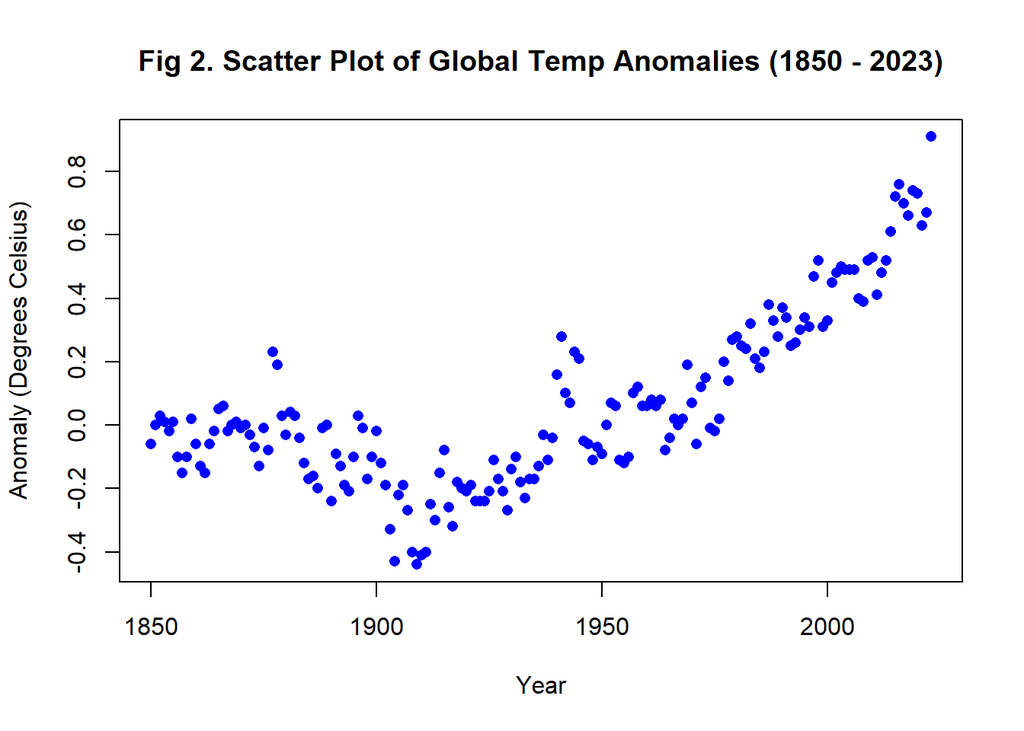

```r
# Create a scatter plot of the time series data
plot(ts_assignment2Data2024, type = "p", pch = 16, col = "blue",
     main = "Fig 2. Scatter Plot of Global Temp Anomalies (1850 - 2023)",
     xlab = "Year", ylab = "Anomaly (Degrees Celsius)")
```

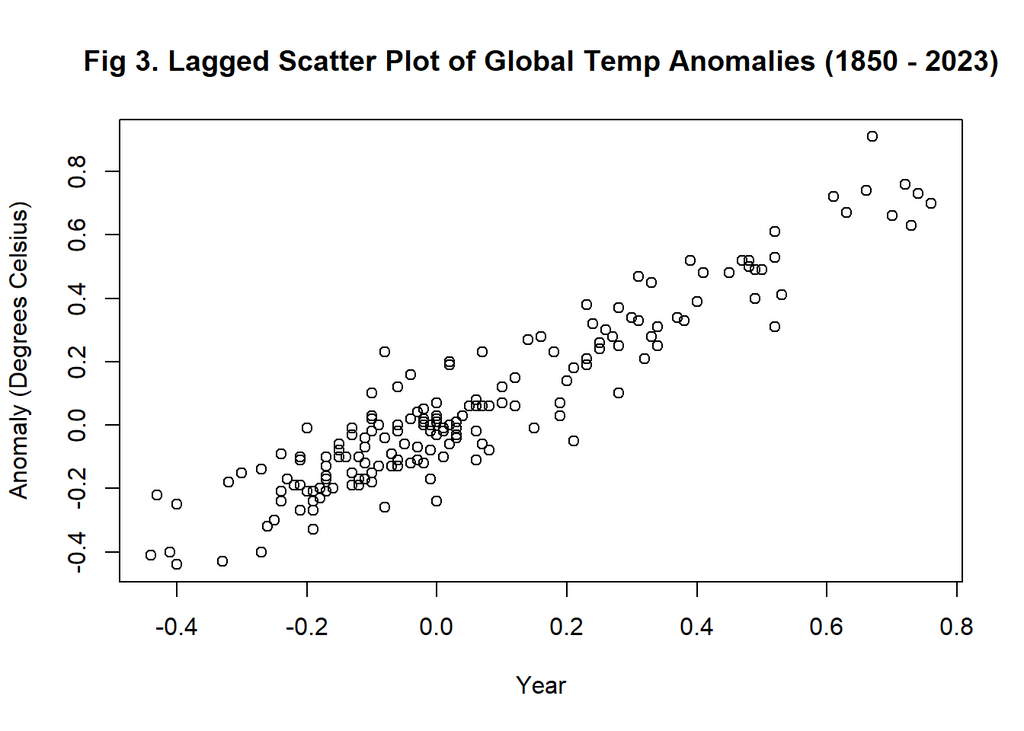

```r
# Create a Lagged scatter plot of the time series data to show relationship between points
par(mfrow=c(1,1))
plot(y=ts_assignment2Data2024, x=zlag(ts_assignment2Data2024), ylab='Anomaly (Degrees Celsius)', xlab='Year',
     main = "Fig 3. Lagged Scatter Plot of Global Temp Anomalies (1850 - 2023)")
```

The Scatter Plot: Shows individual data points without any connection between them. This provides a visual representation of the distribution of the temperature anomalies over time.

Lagged Scatter Plot: Shows This plot connects each data point with its lagged counterpart, where each point represents the relationship between the temperature anomaly in a given year and its lagged value (e.g., temperature anomaly in the previous year).

Visually inspecting both scatter plots above, we can see that the data points exhibit a discernible linear trend, they form an upward-sloping line from left to right. This observation indicates a positive correlation between the two variables under consideration.

## **1.2.3 Correlation Test of Scatter Plot**

```r
# Read the data into y
y <- ts_assignment2Data2024

# Generate the first lag of the series
x <- zlag(ts_assignment2Data2024)

# Create an index to exclude the first NA value in x if applicable
index <- 2:length(x)

# Calculate the correlation between numerical values in x and y
correlation <- cor(y[index], x[index])

print(correlation)
```

```
## [1] 0.9399931
```

The result 0.9399931 suggests that the correlation coefficient between the variables, y and x has a strong linear relationship between the original time series and its lagged version.

## **1.3 STATIONARITY TEST AND VALIDATION**

## **1.3.1. Breusch-Pagan test for heteroscedasticity**

```r
# Performing the Breusch-Pagan test for heteroscedasticity
anom <- 1:length(ts_assignment2Data2024)

# Fit a linear regression model with an intercept and the "anom" variable
model <- lm(ts_assignment2Data2024 ~ anom)

# Perform the Breusch-Pagan test for heteroscedasticity
bp_test <- bptest(model)

# Print the test results
print(bp_test)
```

```
##
##  studentized Breusch-Pagan test
##
## data:  model
## BP = 0.11734, df = 1, p-value = 0.7319
```

The Breusch-Pagan test which is used to test for heteroscedasticity shows that our p-value of 0.7319 is greater than the typical significance level of 0.05. This indicates that the assumptions of constant variance of errors (homoscedasticity) in the regression model are not violated. Hence, It shows the consistency in the variability of our data.

## **1.3.2. Data Visualization - ACF Plot**

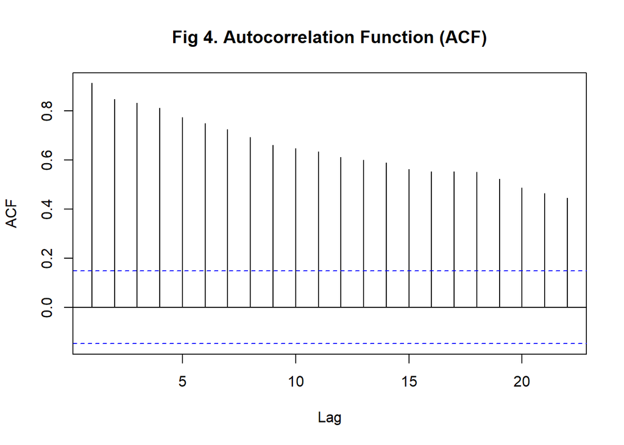

```r
# Plot the ACF and PACF Plot to check for stationarity
par(mfrow=c(1,1))
acf(ts_assignment2Data2024, main = "Fig 4. Autocorrelation Function (ACF)")
```

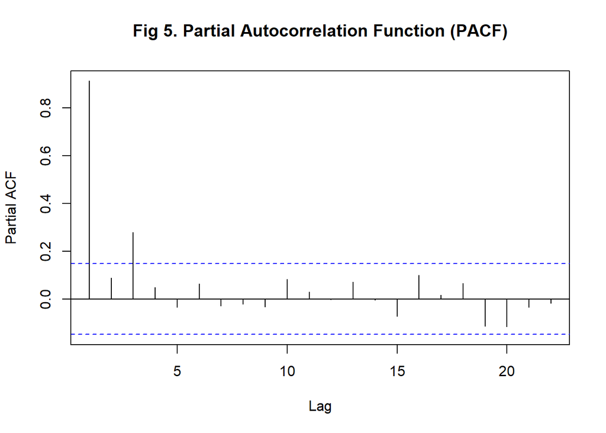

```r
pacf(ts_assignment2Data2024, main = "Fig 5. Partial Autocorrelation Function (PACF)")
```

Partial Autocorrelation (PACF): We can see that the first and third lags are above the confidence line. The significant spike at the first lag indicates a strong correlation between the series and its first lagged value. This suggests the presence of autoregressive behavior. There is also an observable significant spike at the third lag, after a quick dampening from the first lag. The quick dampening after the third lag is a behavior consistent with autoregressive process.

## **1.3.3. Augmented Dickey-Fuller (ADF) Test**

```r
# Perform ADF test
adf.test(ts_assignment2Data2024)
```

```
##
##  Augmented Dickey-Fuller Test
##
## data:  ts_assignment2Data2024
## Dickey-Fuller = -1.1974, Lag order = 5, p-value = 0.9044
## alternative hypothesis: stationary
```

With a p-value of 0.9044, which is greater than the significance level of 0.05, we fail to reject the null hypothesis. The ADF test suggests that the time series may be non-stationary, meaning it may exhibit a trend or other non-constant behavior over time.

## **1.3.4 Kwiatkowski-Phillips-Schmidt-Shin (KPSS) test**

```r
# Perform KPSS test
kpss.test(ts_assignment2Data2024)
```

```
##
##  KPSS Test for Level Stationarity
##
## data:  ts_assignment2Data2024
## KPSS Level = 2.3416, Truncation lag parameter = 4, p-value = 0.01
```

## **1.3.5 Phillips-Perron Unit Root Test**

```r
# Perform PP test
pp.test(ts_assignment2Data2024)
```

```
##
##  Phillips-Perron Unit Root Test
##
## data:  ts_assignment2Data2024
## Dickey-Fuller Z(alpha) = -12.042, Truncation lag parameter = 4, p-value
## = 0.4258
## alternative hypothesis: stationary
```

## **1.3.6 Normality Q-Q Plot with qqline**

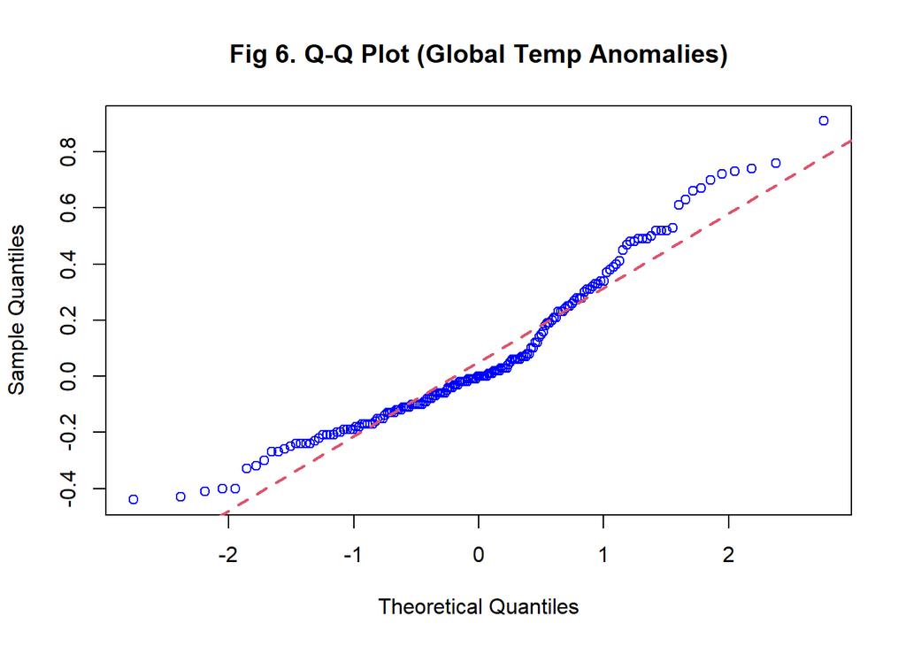

```r
# Q-Q plot with qqline
qqnorm(y = ts_assignment2Data2024, main = "Fig 6. Q-Q Plot (Global Temp Anomalies)", col = "blue")
qqline(y = ts_assignment2Data2024, col = 2, lwd = 2, lty = 2)
```

The Q-Q plot (quantile-quantile plot) shows a divergence at the end of the line. We can assume that the our dataset does not adhere to a normal distribution at both ends of the data point.

## **1.3.7 Shapiro-Wilk normality test**

```r
shapiro.test(ts_assignment2Data2024)
```

```
##
##  Shapiro-Wilk normality test
##
## data:  ts_assignment2Data2024
## W = 0.94279, p-value = 1.897e-06
```

We can confirm that our time series does not follow a normal distribution. With a very low p-value (close to zero), significantly smaller than the typical significance level of 0.05, This shows that our time series - “ts_assignment2Data2024” is not normally distributed.

## **1.3.8 Histogram with Density Plot**

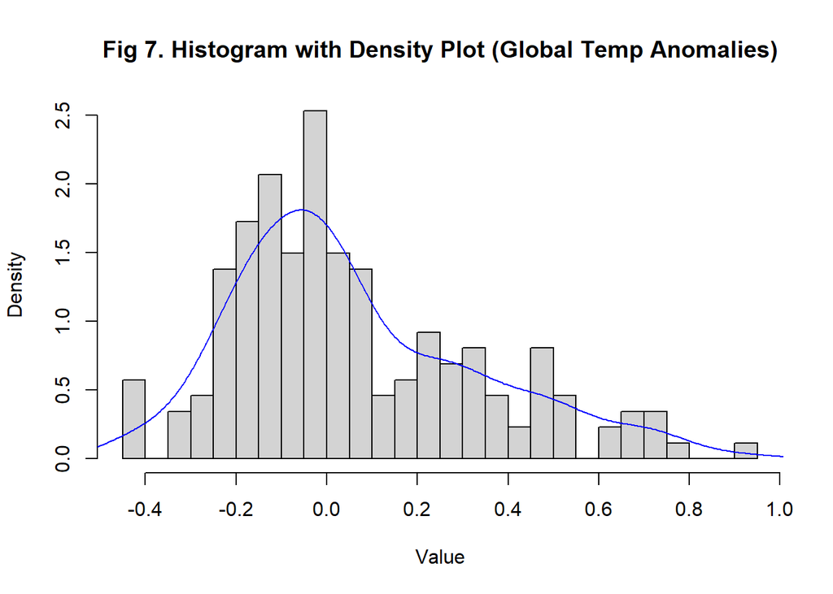

```r
# Create a histogram with a density plot overlay
hist(ts_assignment2Data2024, breaks = 20, freq = FALSE, main = "Fig 7. Histogram with Density Plot (Global Temp Anomalies)", xlab = "Value", ylab = "Density")
lines(density(ts_assignment2Data2024), col = "blue")
```

The histogram shows our dataset is right skewed to our distribution.

## **1.4 ADDRESSING THE NON-STATIONARITY IN OUR TIME SERIES**

## **1.4.1 With Box Cox Transformation**

The Box-Cox transformation is typically used to stabilize the variance of a time series and make it more homoscedastic (having constant variance) and closer to a normal distribution.

```r
# Add a small offset to the data to make it positive
ts_assignment2Data2024_1 <- ts_assignment2Data2024 + abs(min(ts_assignment2Data2024)) + 0.01

# Apply the Box-Cox transformation
BC <- suppressWarnings(BoxCox.ar(y = ts_assignment2Data2024_1, lambda = seq(-3, 3, 0.01)))
```

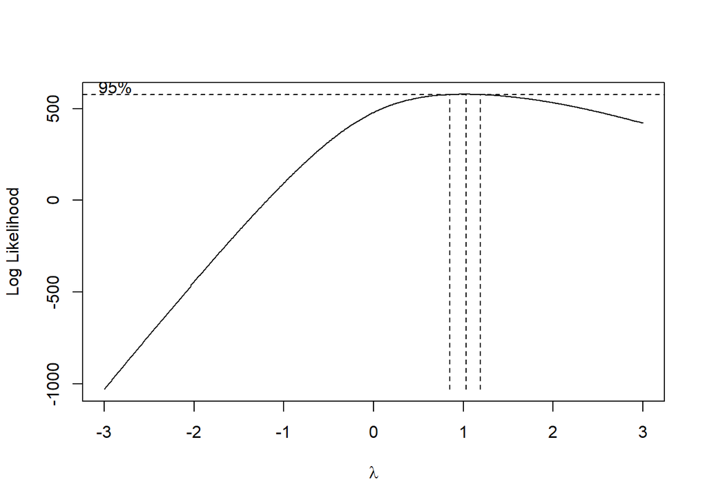

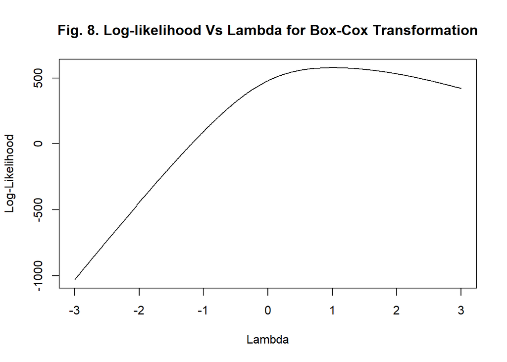

```r
# Plot log-likelihood versus lambda
plot(BC$lambda, BC$loglike, type = "l", xlab = "Lambda", ylab = "Log-Likelihood",
     main = "Fig. 8. Log-likelihood Vs Lambda for Box-Cox Transformation")
```

```r
BC$ci # Values of the first and third vertical lines
```

```
## [1] 0.85 1.19
```

```r
# Find the lambda value corresponding to the maximum log-likelihood
lambda_max <- BC$lambda[which.max(BC$loglike)]

lambda_max
```

```
## [1] 1.03
```

## **1.4.2 Box Cox Transformation: - Orginal Data vs Transformed Data Plot**

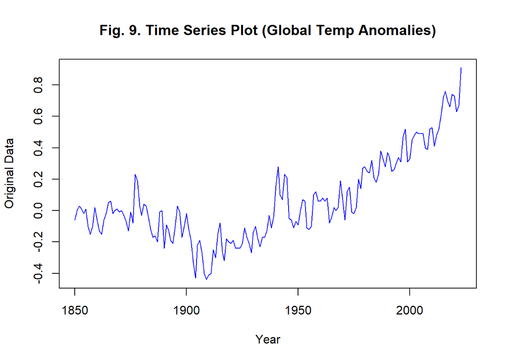

```r
# Original Data Plot
plot(ts_assignment2Data2024,
     type = "l",
     col = "blue",
     xlab = "Year",
     ylab = "Original Data",
     main = "Fig. 9. Time Series Plot (Global Temp Anomalies)")
```

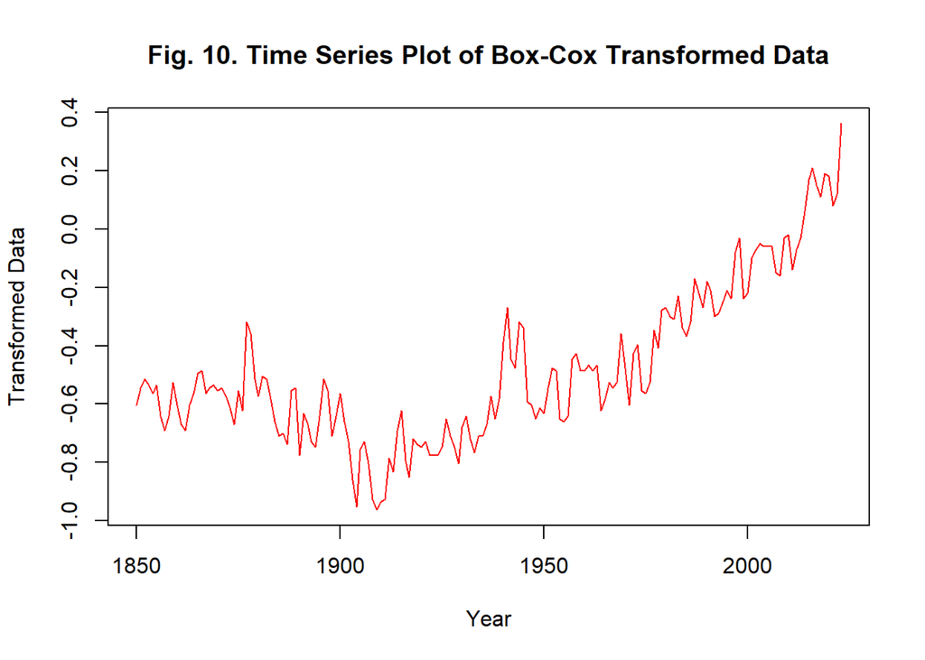

```r
# Box-Cox Transformed Data Plot
BC_ts_assignment2Data2024 <- BoxCox(ts_assignment2Data2024_1, lambda_max)
plot(BC_ts_assignment2Data2024,
     type = "l",
     col = "red",
     xlab = "Year",
     ylab = "Transformed Data",
     main = "Fig. 10. Time Series Plot of Box-Cox Transformed Data")
```

```r
shapiro.test(BC_ts_assignment2Data2024)
```

```
##
##  Shapiro-Wilk normality test
##
## data:  BC_ts_assignment2Data2024
## W = 0.93871, p-value = 8.765e-07
```

Despite the application of the Box-Cox transformation, from Fig. 9, the difference using the Shapiro-Wilk normality was marginal. The p-value = 8.765e-07 is quite far from the ideal significance level (α = 0.05).

## **1.4.3 Q-Q Plot of transformed Data**

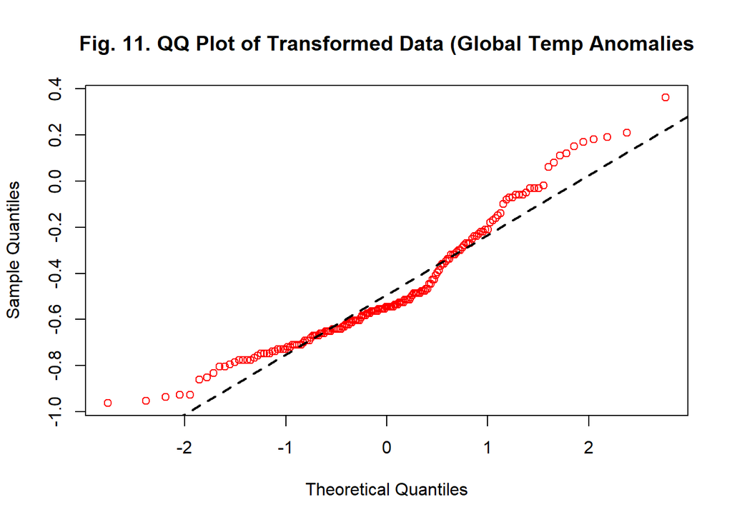

```r
# Create a QQ plot of the transformed data
qqnorm(BC_ts_assignment2Data2024, main = "Fig. 11. QQ Plot of Transformed Data (Global Temp Anomalies", col = "red")

# Add a QQ line to the plot
qqline(y = BC_ts_assignment2Data2024, col = 1, lwd = 2, lty = 2)
```

In the context of a Box-Cox transformation, BC$ci represents the confidence interval for the estimated optimal lambda.max (λ) parameter obtained from the Box-Cox transformation. The output 1.03 indicates that the lambda value associated with the maximum log-likelihood, and thus the middle vertical line in the Box-Cox transformation plot, is approximately 1.03. This lambda value represents the optimal transformation parameter that maximizes the likelihood of the transformed data. The range [0.85, 1.19] indicates that lambda values within this range result in similar maximum log-likelihood values. We can also see that the Box-Cox transformation may not help stabilize the time series data variance; we would therefore focus on other transformation approach to achieve the possibility of normality.

## **1.5 USING DIFFERENCING TO ACHIEVE STATIONARITY**

## **1.5.1 Differencing our Time series**

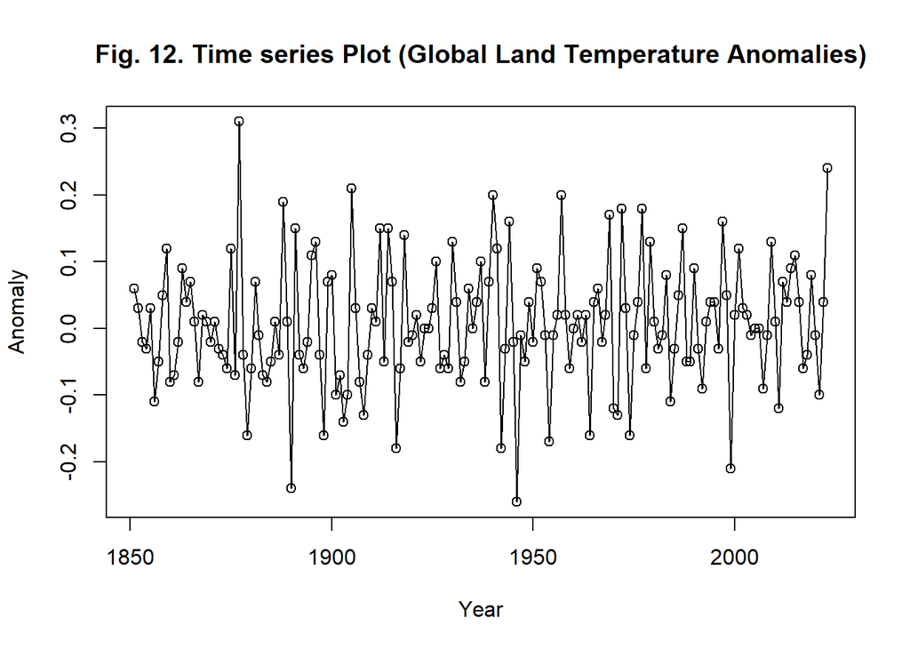

```r
# Applying differencing to the Time series
ts_assignment2Data2024_diff <- diff(ts_assignment2Data2024, differences = 1)

# Plotting the differenced series
plot(ts_assignment2Data2024_diff, ylab = "Anomaly", xlab = "Year",
     main = "Fig. 12. Time series Plot (Global Land Temperature Anomalies)", type="o")
```

## **1.5.2 Confirming Stationarity**

```r
# Perform ADF test
adf.test(ts_assignment2Data2024_diff)
```

```
##
##  Augmented Dickey-Fuller Test
##
## data:  ts_assignment2Data2024_diff
## Dickey-Fuller = -7.0878, Lag order = 5, p-value = 0.01
## alternative hypothesis: stationary
```

With a p-value of 0.01, which is less than the significance level of 0.05, we reject the null hypothesis. Therefore, based on the ADF test results, we have sufficient evidence to conclude that the differenced time series ts_assignment2Data2024_diff is stationary.

## **1.5.1.1. Kwiatkowski-Phillips-Schmidt-Shin (KPSS) test**

```r
# Perform KPSS test
kpss.test(ts_assignment2Data2024_diff)
```

```
##
##  KPSS Test for Level Stationarity
##
## data:  ts_assignment2Data2024_diff
## KPSS Level = 0.24108, Truncation lag parameter = 4, p-value = 0.1
```

With the p-value (0.1) which is greater than the significance level, we fail to reject the null hypothesis. Therefore, based on the KPSS test results, there is insufficient evidence to conclude that the differenced time series ts_assignment2Data2024_diff is non-stationary around a deterministic trend.

## **1.5.1.2. Phillips-Perron Unit Root Test**

```r
# Perform PP test
pp.test(ts_assignment2Data2024_diff)
```

```
##
##  Phillips-Perron Unit Root Test
##
## data:  ts_assignment2Data2024_diff
## Dickey-Fuller Z(alpha) = -136.61, Truncation lag parameter = 4, p-value
## = 0.01
## alternative hypothesis: stationary
```

With a p-value (0.01) is less than the significance level, we reject the null hypothesis. Therefore, based on the PP test results, we have sufficient evidence to conclude that the differenced time series ts_assignment2Data2024_diff is stationary.

## **1.6. MODEL SPECIFICATION AND FITTTING**

Using ARIMA (AutoRegressive Integrated Moving Average) models provides a widely used context in time series forecasting techniques. For determining the best model, we would use a combination of steps/processes. such as Auto.Arima, EACF, BIC and ACF, PACF.

## **1.6.1 Approach 1: - Using ACF - PACF of First Differenced Time Series**

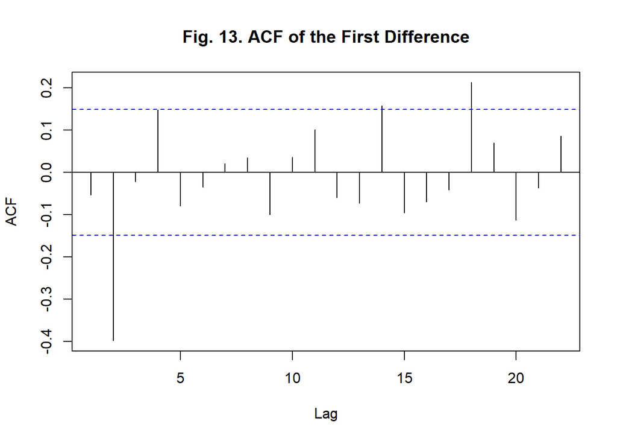

```r
# Plot the ACF of the first differenced time series
acf(ts_assignment2Data2024_diff, main = "Fig. 13. ACF of the First Difference")
```

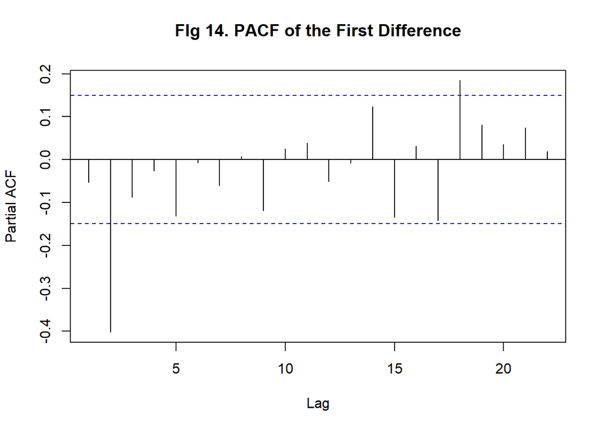

```r
# Plot the PACF of the first differenced time series
pacf(ts_assignment2Data2024_diff, main = "FIg 14. PACF of the First Difference")
```

## **1.6.2. Approach 2: - Using EACF Plot**

```r
# Generate EACF plot
eacf_plot <- eacf(ts_assignment2Data2024_diff, ar.max = 14, ma.max = 14)
```

```
## AR/MA
##    0 1 2 3 4 5 6 7 8 9 10 11 12 13 14
## 0  o x o o o o o o o o o  o  o  o  o
## 1  o x o o o o o o o o o  o  o  o  o
## 2  x o x o o o o o o o o  o  o  o  o
## 3  x o x o o o o o o o o  o  o  o  o
## 4  x x x o o o o o o o o  o  o  o  o
## 5  o x o o o o x o o o o  o  o  o  o
## 6  x x o x o o x o o o o  o  o  o  o
## 7  x x o x x o o o o o o  o  o  o  o
## 8  o x o x o o o o o o o  o  o  o  o
## 9  o x x x x x x o o o o  o  o  o  o
## 10 x o x o o o o x o o o  o  o  o  o
## 11 x x o o o o o x o o o  o  o  o  o
## 12 x x x o o o o o o o o  o  o  o  o
## 13 x x o x o o o o o o o  o  o  o  o
## 14 x x o o o o o o o o o  o  o  o  o
```

## **1.6.3. Approach 3: - BIC Table**

```r
# Generate BIC table for subset ARIMA models
bic_table <- armasubsets(y = ts_assignment2Data2024_diff, nar = 4, nma = 4, y.name = "ts_assignment2Data2024_diff", ar.method = "ols")
```

```
## Reordering variables and trying again:
```

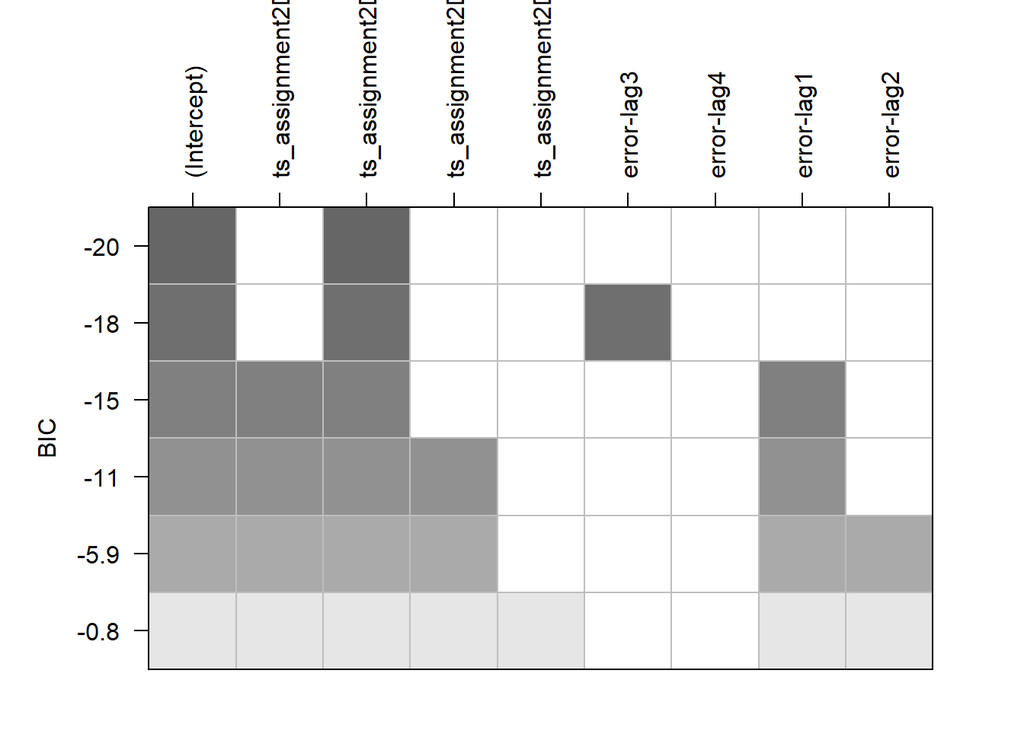

```r
# Plot the BIC table
plot(bic_table)
```

## **1.6.4 Approach 4: - Using AUTO ARIMA Function**

```r
auto.arima(ts_assignment2Data2024, trace = TRUE)
```

```
##
##  Fitting models using approximations to speed things up...
##
##  ARIMA(2,1,2) with drift         : -344.9453
##  ARIMA(0,1,0) with drift         : -319.6611
##  ARIMA(1,1,0) with drift         : -317.4408
##  ARIMA(0,1,1) with drift         : -320.6917
##  ARIMA(0,1,0)                    : -321.0892
##  ARIMA(1,1,2) with drift         : -345.6942
##  ARIMA(0,1,2) with drift         : -348.364
##  ARIMA(0,1,3) with drift         : -346.9123
##  ARIMA(1,1,1) with drift         : -333.0038
##  ARIMA(1,1,3) with drift         : -349.4323
##  ARIMA(2,1,3) with drift         : -345.3634
##  ARIMA(1,1,4) with drift         : -346.1384
##  ARIMA(0,1,4) with drift         : -348.1132
##  ARIMA(2,1,4) with drift         : -343.2256
##  ARIMA(1,1,3)                    : -348.4185
##
##  Now re-fitting the best model(s) without approximations...
##
##  ARIMA(1,1,3) with drift         : -354.8723
##
##  Best model: ARIMA(1,1,3) with drift
```

```
## Series: ts_assignment2Data2024
## ARIMA(1,1,3) with drift
##
## Coefficients:
##           ar1     ma1      ma2      ma3   drift
##       -0.9579  0.8500  -0.5480  -0.4684  0.0048
## s.e.   0.0394  0.0777   0.0827   0.0679  0.0027
##
## sigma^2 = 0.00718:  log likelihood = 183.69
## AIC=-355.38   AICc=-354.87   BIC=-336.46
```

The EACF plot offers insights into potential ARIMA (AutoRegressive Integrated Moving Average) models by displaying combinations of possible AutoRegressive (AR) and Moving Average (MA) terms. Each row represents a potential AR order, while each column represents a potential MA order. Symbols such as “o” and “x” indicate the appropriateness of each term for modeling the data.

From the output, the following can be taken into consideration:

- The presence of “o” suggests the term may be suitable for inclusion.
- Conversely, “x” indicates that the term is less likely to be appropriate.

The observed “o” and “x” patterns in the plot lead to the identification of several candidate ARIMA models, including variations such as ARIMA(3,1,3), ARIMA(3,1,2), ARIMA(2,1,3), etc.

Further analysis involves considering additional candidate models based on both the EACF plot and other criteria such as the Bayesian Information Criterion (BIC) table and the Auto-ARIMA function: Candidate Models like ARIMA(0,1,0), ARIMA(1,1,0), ARIMA(1,1,2), ARIMA(0,1,3), and ARIMA(1,1,1) are identified based on the “o” marks in the EACF plot, indicating potential ARIMA terms.

Additional candidate models, such as ARIMA(2,1,2), ARIMA(1,1,4), ARIMA(0,1,4), etc., are derived from the Auto-ARIMA function. In summary, the analysis utilizes the EACF plot, BIC table, and Auto-ARIMA function to identify a range of potential ARIMA models, considering various combinations of AR and MA terms along with differencing orders. These candidate models provide a basis for further evaluation and selection of the most suitable model for the time series data.

## **1.6.5 Testing our candidate models with Box - Ljung Test**

```r
# Define the candidate models
candidate_models <- list(
  ARIMA_001 = c(0, 1, 0),
  ARIMA_110 = c(1, 1, 0),
  ARIMA_112 = c(1, 1, 2),
  ARIMA_013 = c(0, 1, 3),
  ARIMA_111 = c(1, 1, 1),
  ARIMA_113 = c(1, 1, 3),
  ARIMA_212 = c(2, 1, 2),
  ARIMA_011 = c(0, 1, 1),
  ARIMA_012 = c(0, 1, 2),
  ARIMA_213 = c(2, 1, 3),
  ARIMA_114 = c(1, 1, 4),
  ARIMA_014 = c(0, 1, 4),
  ARIMA_214 = c(2, 1, 4)
)

# Function to perform Box-Ljung test for a given model
perform_box_ljung_test <- function(model_order, ts_assignment2Data2024) {
  model <- Arima(ts_assignment2Data2024, order = model_order)
  residuals <- resid(model)

  # Perform Box-Ljung test
  box_ljung_test <- Box.test(residuals, lag = 20, type = "Ljung-Box")

  return(box_ljung_test)
}

# Perform Box-Ljung test for each candidate model
box_ljung_test_results <- lapply(candidate_models, function(model_order) {
  perform_box_ljung_test(model_order, ts_assignment2Data2024)
})

# Print the results
names(box_ljung_test_results) <- names(candidate_models)
print(box_ljung_test_results)
```

```
## $ARIMA_001
##
##  Box-Ljung test
##
## data:  residuals
## X-squared = 60.234, df = 20, p-value = 6.551e-06
##
##
## $ARIMA_110
##
##  Box-Ljung test
##
## data:  residuals
## X-squared = 60.058, df = 20, p-value = 6.977e-06
##
##
## $ARIMA_112
##
##  Box-Ljung test
##
## data:  residuals
## X-squared = 30.91, df = 20, p-value = 0.05639
##
##
## $ARIMA_013
##
##  Box-Ljung test
##
## data:  residuals
## X-squared = 30.677, df = 20, p-value = 0.0596
##
##
## $ARIMA_111
##
##  Box-Ljung test
##
## data:  residuals
## X-squared = 41.186, df = 20, p-value = 0.003526
##
##
```

[output cut: 47 more lines]

```
##
## $ARIMA_014
##
##  Box-Ljung test
##
## data:  residuals
## X-squared = 25.329, df = 20, p-value = 0.1891
##
##
## $ARIMA_214
##
##  Box-Ljung test
##
## data:  residuals
## X-squared = 23.756, df = 20, p-value = 0.2532
```

ARIMA_001, ARIMA_110, ARIMA_111, and ARIMA_011 have small p-values (< 0.05), indicating significant autocorrelation in the residuals. The other models have p-values greater than 0.05, suggesting no significant autocorrelation in the residuals at a typical significance level of 0.05. However, it’s essential to interpret these results cautiously and consider additional diagnostics and model evaluation criteria.

## **1.6.6 Testing our candidate models with Shapiro-Wilk normality test**

```r
# Define the candidate models
candidate_models <- list(
  ARIMA_001 = c(0, 1, 0),
  ARIMA_110 = c(1, 1, 0),
  ARIMA_112 = c(1, 1, 2),
  ARIMA_013 = c(0, 1, 3),
  ARIMA_111 = c(1, 1, 1),
  ARIMA_113 = c(1, 1, 3),
  ARIMA_212 = c(2, 1, 2),
  ARIMA_011 = c(0, 1, 1),
  ARIMA_012 = c(0, 1, 2),
  ARIMA_213 = c(2, 1, 3),
  ARIMA_114 = c(1, 1, 4),
  ARIMA_014 = c(0, 1, 4),
  ARIMA_214 = c(2, 1, 4)
)

# Function to perform Shapiro-Wilk test for a given model
perform_shapiro_wilk_test <- function(model_order, ts_assignment2Data2024) {
  model <- Arima(ts_assignment2Data2024, order = model_order)
  residuals <- resid(model)

  # Perform Shapiro-Wilk test
  shapiro_wilk_test <- shapiro.test(residuals)

  return(shapiro_wilk_test)
}

# Perform Shapiro-Wilk test for each candidate model
shapiro_wilk_test_results <- lapply(candidate_models, function(model_order) {
  perform_shapiro_wilk_test(model_order, ts_assignment2Data2024)
})

# Print the results
names(shapiro_wilk_test_results) <- names(candidate_models)
print(shapiro_wilk_test_results)
```

```
## $ARIMA_001
##
##  Shapiro-Wilk normality test
##
## data:  residuals
## W = 0.99039, p-value = 0.2921
##
##
## $ARIMA_110
##
##  Shapiro-Wilk normality test
##
## data:  residuals
## W = 0.99197, p-value = 0.4456
##
##
## $ARIMA_112
##
##  Shapiro-Wilk normality test
##
## data:  residuals
## W = 0.98344, p-value = 0.03674
##
##
## $ARIMA_013
##
##  Shapiro-Wilk normality test
##
## data:  residuals
## W = 0.98392, p-value = 0.04241
##
##
## $ARIMA_111
##
##  Shapiro-Wilk normality test
##
## data:  residuals
## W = 0.99295, p-value = 0.5639
##
##
```

[output cut: 47 more lines]

```
##
## $ARIMA_014
##
##  Shapiro-Wilk normality test
##
## data:  residuals
## W = 0.9775, p-value = 0.00637
##
##
## $ARIMA_214
##
##  Shapiro-Wilk normality test
##
## data:  residuals
## W = 0.97558, p-value = 0.00371
```

Based on the p-values:

ARIMA_001, ARIMA_110, ARIMA_111, and ARIMA_011 have large p-values (> 0.05), indicating that the residuals are likely normally distributed. The other models have small p-values (< 0.05), suggesting that the residuals may not follow a normal distribution.